# Best practices

October 2019

## Reproducible pipeline

*…This places an obligation on all creators of software to program in such a way that the computations can be understood and trusted. This obligation I label the Prime Directive.*

- John Chambers (Software for Data Analysis: Programming with R)

## Adaptive management

- Ideally, we can rerun all decision support tools over and over again
- Must be MUCH easier the second, third, etc. time
- If there is an incremental change in input data, then we shouldn’t need to redo the same effort as the first time around (e.g., `Cache`).

## Why reproducible?

- Rerun analysis/model
- New computer or new team member
- Rebuild a figure (e.g., for publication)
- Address reviewer comments prior to publication
- Quickly update with new data
- Quickly update downstream reporting
- Defendability & transparency

**Beyond reproducibility: *reusablility***

## Open-ness and accessibility

- facilitate reusability & sharing
- increased densibility & transparency
- should be *freely available*

## Interoperability

- modular design
- facilitate integration

## Continuous workflow

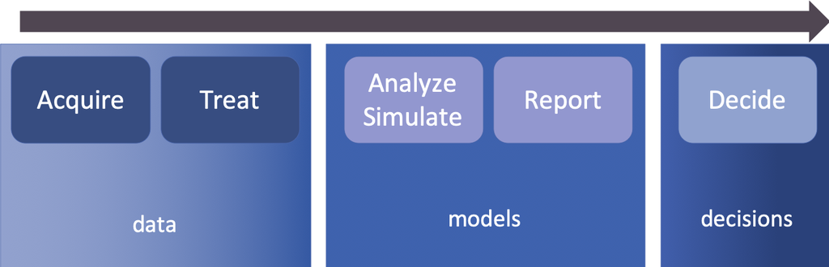

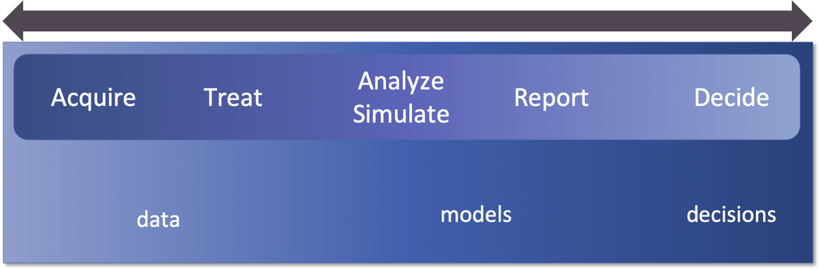

## Automatic testing

- R package infrastructure is tested daily by CRAN
- `SpaDES` family of packages tested everytime code committed

**but what about SpaDES modules?**

- unit tests (currently need to be run manually)

## The ‘PERFICT’ approach

**P**redictive **E**cology that is

- **R**eusable,
- **F**reely available,
- **I**nteroperable,
- use a **C**ontinuous workflow,
- **T**ested automatically.

Substantial immediate and long-term benefits, at the [minor] cost of (re)learning and modifying current workflows

## Data-to-decisions

> What is `SpaDES`?

```
a. an R package (or family of packages) for sequencing model events;
b. a modelling philosophy;
c. an implementation of PERFICT;
d. all of the above.
```

*Bringing the best science, data, models into the hands of policy makers in real time, on their phones*

## Best practices

## Working with spatial data and simulations

http://www.alexchubaty.com/r-talks/spatial-data-best-practices/spatial-data-best-practices.html#/4